# Question

Determine $z$ such that $P(|Z|<z)=0.46$. In other words, how far from 0 should boundaries be set such that 46% of standard normal values are between those boundaries? (Answers within 0.01 from the correct value will be marked correct.)

# Solution

Start with a sketch.

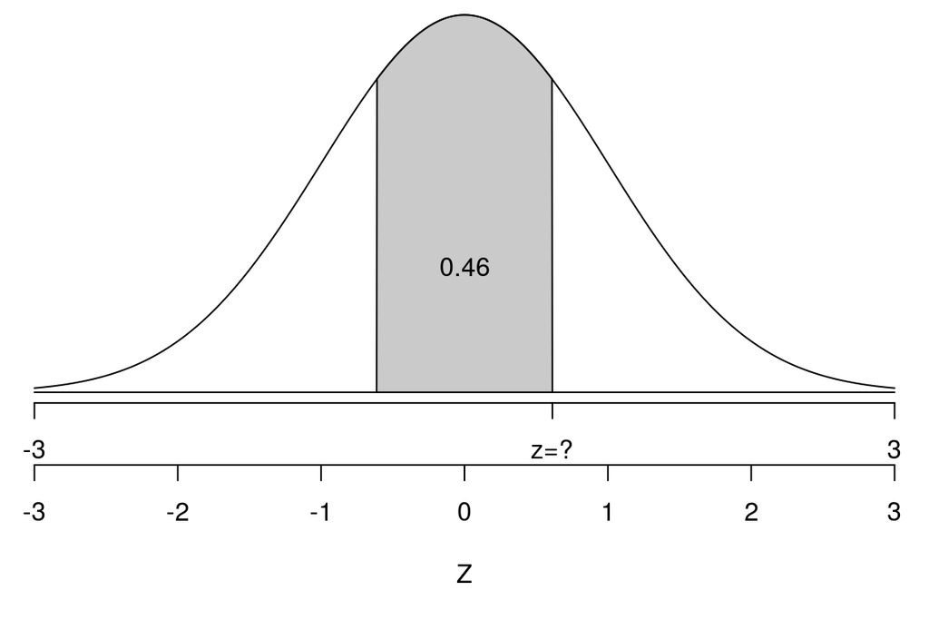

**Method 1:** Determine the area of each tail. Both tails have the same area, and all three areas add to 1. Thus,
$$P(Z>z) = \frac{1-0.46}{2} = 0.27$$

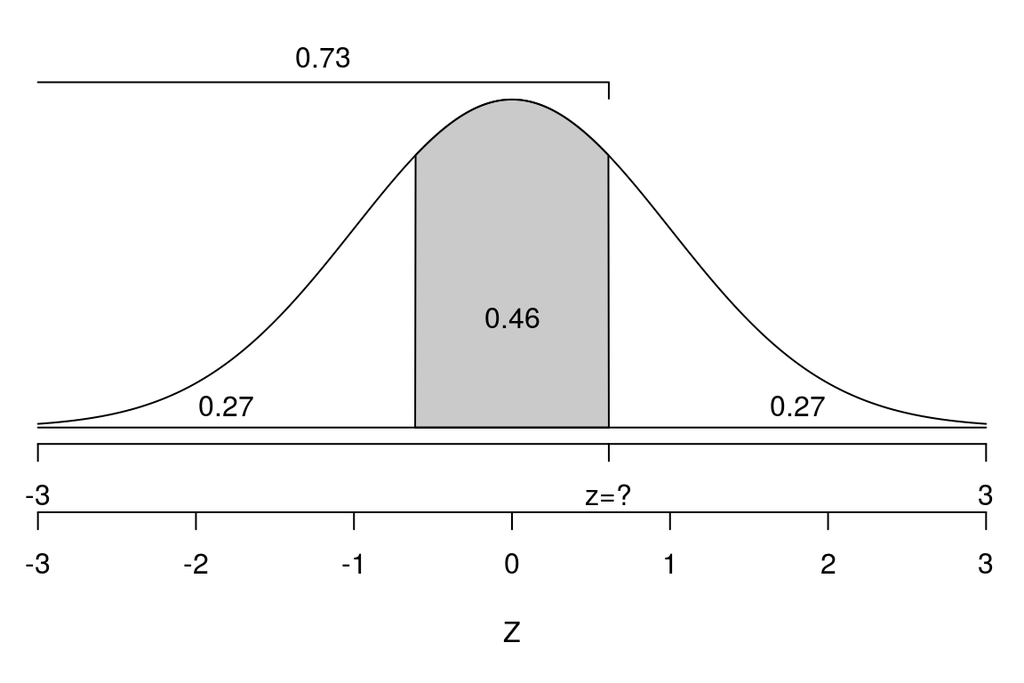

$$\begin{aligned}
P(Z<z) &= 0.27+0.46 \\
&= 0.73
\end{aligned}$$

You should go to your $z$-table and find the $z$-score with the left area closest to 0.73.

| $z$ | $P(Z<z)$ |
| --- | --- |
| 0.59 | 0.7224 |
| 0.6 | 0.7257 |
| **0.61** | **0.7291** |
| **0.62** | **0.7324** |
| 0.63 | 0.7357 |
| 0.64 | 0.7389 |

It turns out the exact answer is 0.612813, which could be found by using an inverse normal function. Like InvNorm(0.73) on a TI calculator, Norm.Inv(0.73) on a spreadsheet, or qnorm(0.73) in R.

But, because we are using the $z$-table, I will accept either 0.61 or 0.62. (Or, really anything within 0.011 of 0.612813.)

**Method 2:** Another way to get 0.73 is by adding half of 0.46 to 0.5.
$$P(Z<z) ~=~ \frac{0.46}{2}+0.5~=~ 0.23+0.5 ~=~ 0.73$$

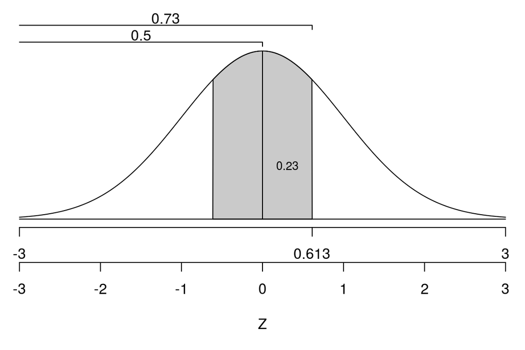

Then, use the table.

# Meta-information

extype: num exsolution: 0.612813 exname: Get z from cental area extol: 0.011